# Reproducible Research: Peer Assessment 1 Submitted by Anandraj

## Loading and preprocessing the data

Load the data from file using read.csv()

```r
    df      <- read.csv("activity.csv")
```

## What is mean total number of steps taken per day?

Make a histogram of the total number of steps taken each day

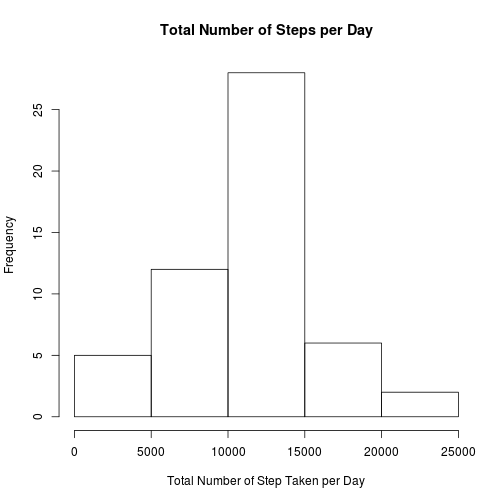

```r
stepsum <- aggregate(df$steps,list(df$date),sum)
hist(stepsum$x,xlab = "Total Number of Step Taken per Day",main="Total Number of Steps per Day")
```

Mean and Median total number of steps taken per day Mean Steps taken

```r
aggregate(x=df$steps,list(df$date),function(x) mean(x,na.rm=T))
```

```
##       Group.1       x
## 1  2012-10-01     NaN
## 2  2012-10-02  0.4375
## 3  2012-10-03 39.4167
## 4  2012-10-04 42.0694
## 5  2012-10-05 46.1597
## 6  2012-10-06 53.5417
## 7  2012-10-07 38.2465
## 8  2012-10-08     NaN
## 9  2012-10-09 44.4826
## 10 2012-10-10 34.3750
## 11 2012-10-11 35.7778
## 12 2012-10-12 60.3542
## 13 2012-10-13 43.1458
## 14 2012-10-14 52.4236
```

[output cut: 47 more lines]

Median of Steps taken

```r
aggregate(x=df$steps,list(df$date),function(x) median(x,na.rm=T))
```

```
##       Group.1  x
## 1  2012-10-01 NA
## 2  2012-10-02  0
## 3  2012-10-03  0
## 4  2012-10-04  0
## 5  2012-10-05  0
## 6  2012-10-06  0
## 7  2012-10-07  0
## 8  2012-10-08 NA
## 9  2012-10-09  0
## 10 2012-10-10  0
## 11 2012-10-11  0
## 12 2012-10-12  0
## 13 2012-10-13  0
## 14 2012-10-14  0
```

[output cut: 47 more lines]

## What is the average daily activity pattern?

Time series plot (i.e. type = “l”) of the 5-minute interval (x-axis) and the average number of steps taken, averaged across all days (y-axis)

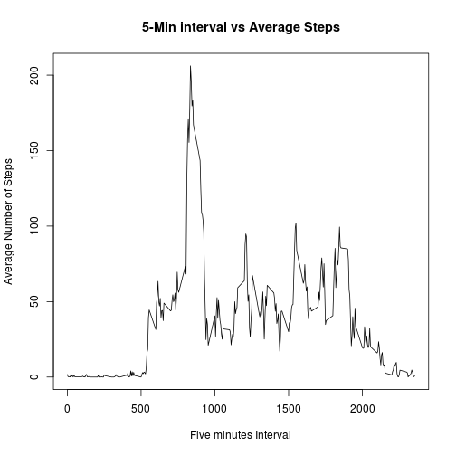

```r
meanbyinterval <- aggregate(x=df$steps,list(df$interval),function(x) mean(x,na.rm=T))
plot(meanbyinterval$x ~ meanbyinterval$Group.1,type="l",xlab="Five minutes Interval",ylab="Average Number of Steps", main ="5-Min interval vs Average Steps")
```

Which 5-minute interval, on average across all the days in the dataset, contains the maximum number of steps?

```r
meanbyinterval[meanbyinterval$x==max(meanbyinterval$x),]$Group.1
```

```
## [1] 835
```

## Imputing missing values

To create the new dataset by imputing missing values copy original dataset df to dfout.

```r
dfout <- df
```

To impute the values use a for loop to select the rows with missing values then assign the intervalmean to that value.

```r
for (i in which(is.na(dfout$steps)))
{
dfout$steps[i] <- meanbyinterval[meanbyinterval$Group.1 == dfout[i,3],2]
}
```

Histogram of the total number of steps taken each day after imputing values

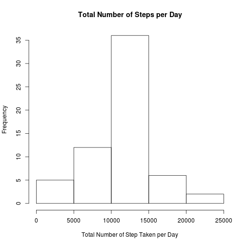

```r
stepsum <- aggregate(dfout$steps,list(dfout$date),sum)
hist(stepsum$x,xlab = "Total Number of Step Taken per Day",main="Total Number of Steps per Day")
```

Calculate and report the mean and median total number of steps taken per day Mean of Steps for each day

```r
aggregate(x=dfout$steps,list(dfout$date),function(x) mean(x,na.rm=T))
```

```
##       Group.1       x
## 1  2012-10-01 37.3826
## 2  2012-10-02  0.4375
## 3  2012-10-03 39.4167
## 4  2012-10-04 42.0694
## 5  2012-10-05 46.1597
## 6  2012-10-06 53.5417
## 7  2012-10-07 38.2465
## 8  2012-10-08 37.3826
## 9  2012-10-09 44.4826
## 10 2012-10-10 34.3750
## 11 2012-10-11 35.7778
## 12 2012-10-12 60.3542
## 13 2012-10-13 43.1458
## 14 2012-10-14 52.4236
```

[output cut: 47 more lines]

Median of Steps for each day

```r
aggregate(x=dfout$steps,list(dfout$date),function(x) median(x,na.rm=T))
```

```
##       Group.1     x
## 1  2012-10-01 34.11
## 2  2012-10-02  0.00
## 3  2012-10-03  0.00
## 4  2012-10-04  0.00
## 5  2012-10-05  0.00
## 6  2012-10-06  0.00
## 7  2012-10-07  0.00
## 8  2012-10-08 34.11
## 9  2012-10-09  0.00
## 10 2012-10-10  0.00
## 11 2012-10-11  0.00
## 12 2012-10-12  0.00
## 13 2012-10-13  0.00
## 14 2012-10-14  0.00
```

[output cut: 47 more lines]

## Are there differences in activity patterns between weekdays and weekends?

Create a new factor variable to indicate if Weekend or Weekday

```r
wd <- rep("day",length(dfout$date))
wd[which(!(weekdays(as.Date(dfout$date,format="%Y-%m-%d")) %in% c("Saturday","Sunday")))] <- "Weekday"
wd[which(weekdays(as.Date(dfout$date,format="%Y-%m-%d")) %in% c("Saturday","Sunday"))] <- "Weekend"
wd <- as.factor(wd)
```

Average steps across 5-Min interval split by Weekday & Weekdends

```r
meanbyintday <- aggregate(x=dfout$steps,list(df$interval,wd),function(x) mean(x,na.rm=T))
```

Plot the difference in Pattern

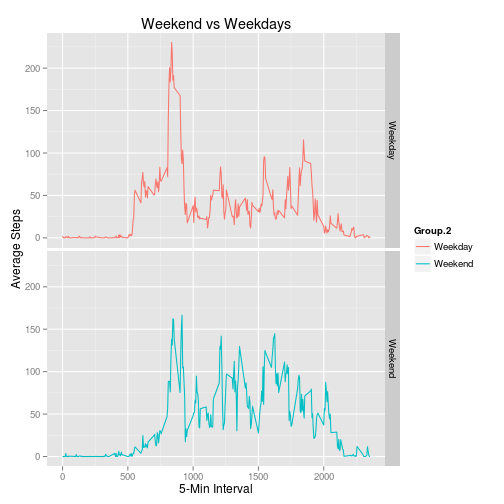

```r
library("ggplot2")
qplot(Group.1,x,data=meanbyintday,geom="line",facets=Group.2~.,color=Group.2,xlab="5-Min Interval",ylab="Average Steps",main="Weekend vs Weekdays")
```